# Disclaimer and Plot Key

2019-10-25 13:51:01

# Disclaimer

# Plot Legend Key

The various plots generated by the tool are shown below with a description of the major points.

Legend for various plots generated by the tool.

## Box Plots, General

Box plots are used in many of the graphical representations of the data. Below is the USGS standard key for box plots (https://owi.usgs.gov/blog/boxplots/).

Some box plots are rotated 90 degrees to allow for more values to be included on the plot.

Some box plots include additional points that are color coded. These points are placed on the plot to show the distribution of select groups; e.g., reference, cluster, sites with better biological scores, target site, etc. The points are placed using the “jitter” command. The jittering adds a small amount of random variation (x and y) to the location of the points so they are easier to visualize. Thus the points should not be considered as exact locations and will be different each time the plots are generated.

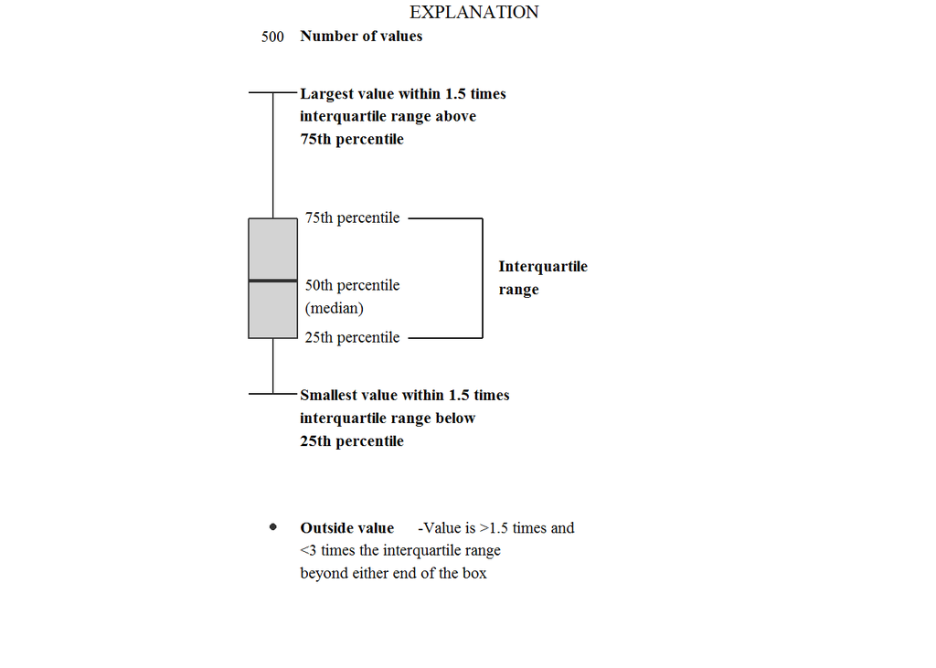

## Site Info

### Map, Static

The static map is all sites in entire region of interest alont with NHD+ flowlines.

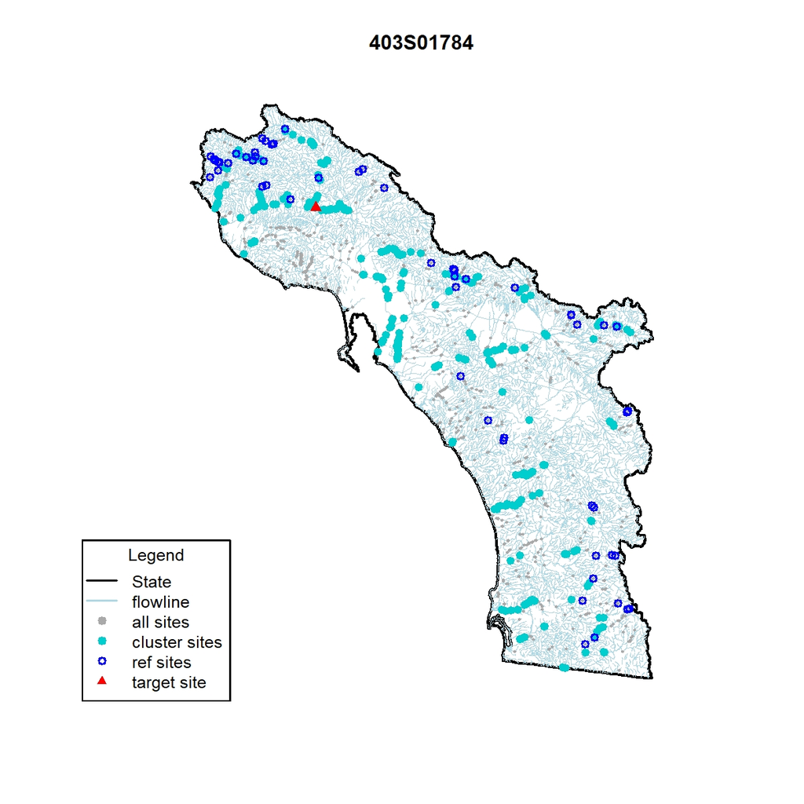

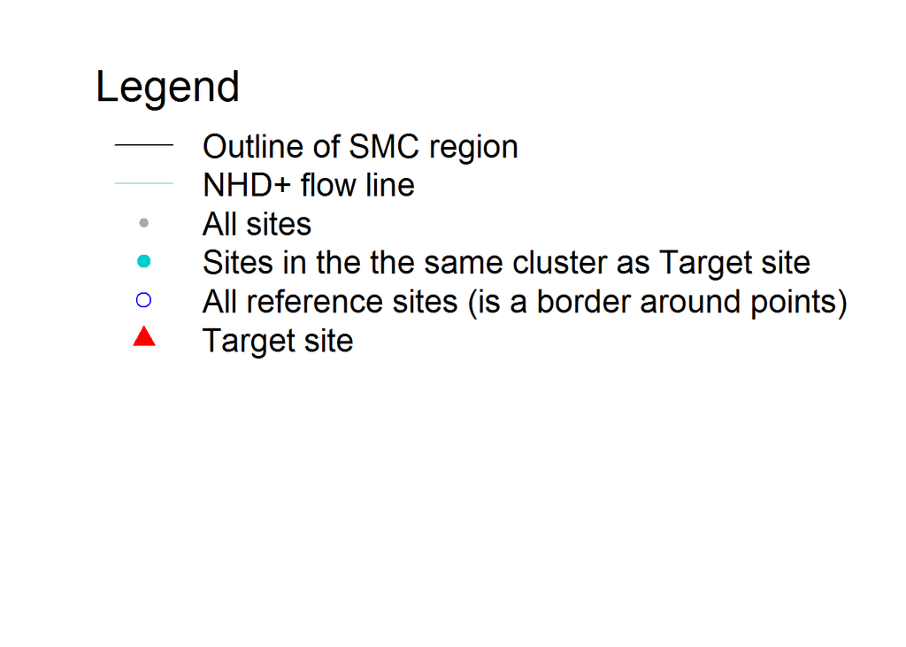

### Map, Interactive

The interactive map behaves much like Google Earth.

The points have the same color coding as the static map.

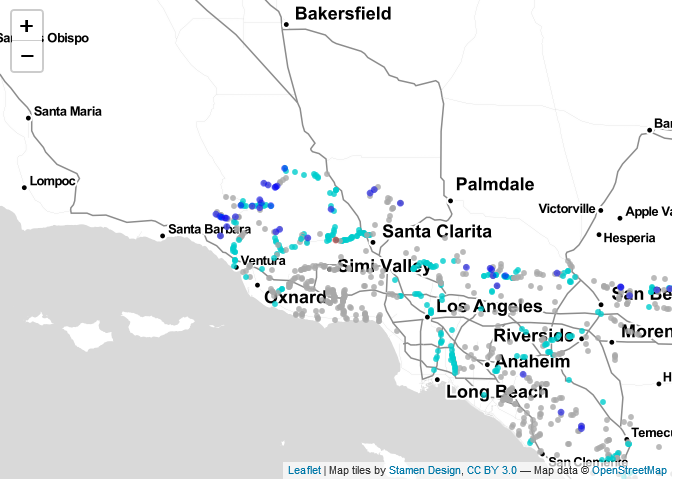

### Potential Anthropogenic Alteration Plots

Bar plots for target site with metrics from StreamCat. Most plots have panels or facets that subdivide the data into categories. The numbers above the bars is the value of the bar.

The color of the bars is a shade of red to associated it with the “target” site.

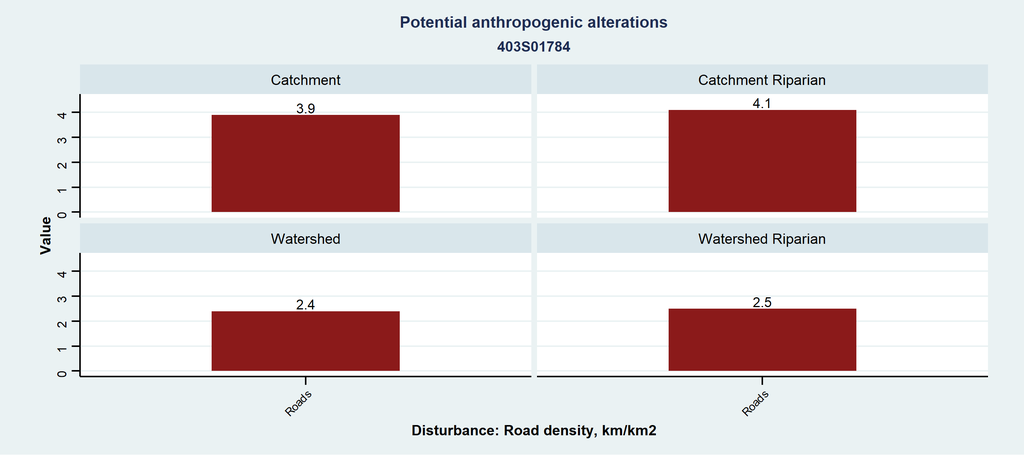

## Candidate Causes

Box plots by stressor category.

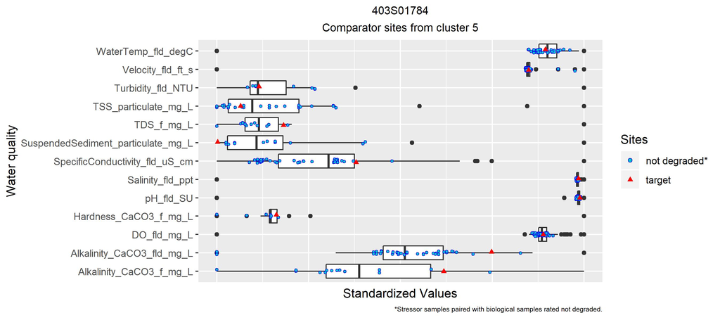

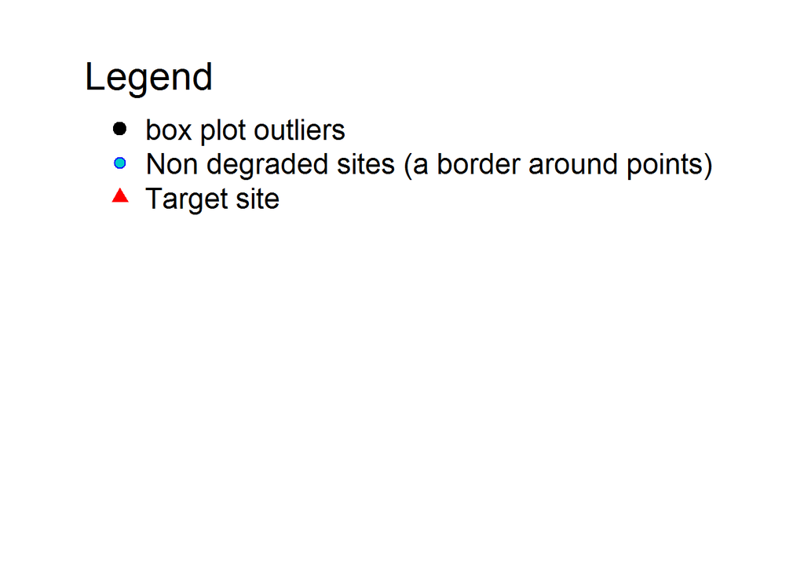

## CoOccurrence

Box plot and Stressor Response

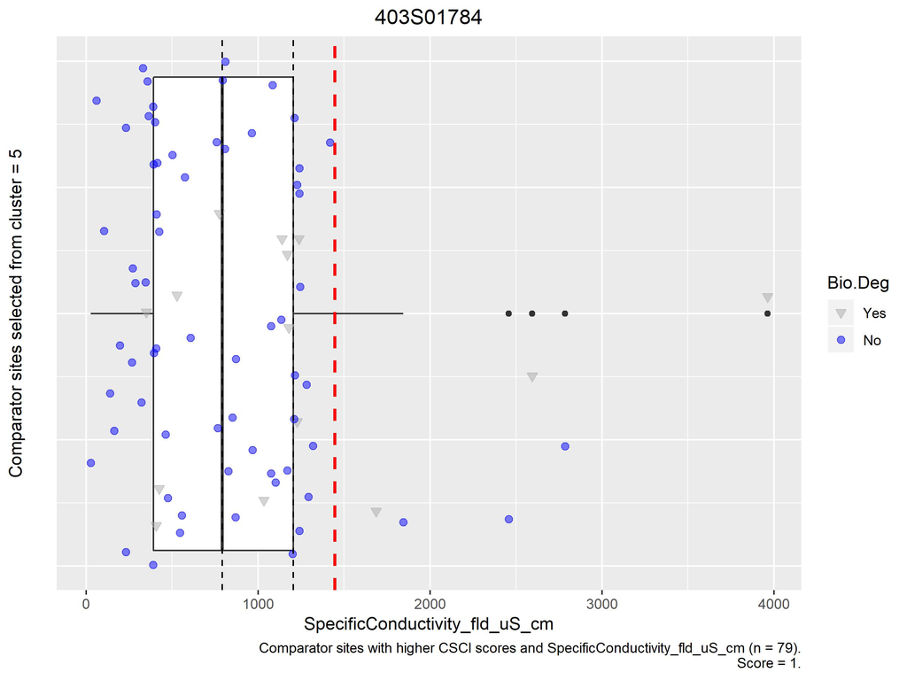

[figure not shown]

Red line = target site

points are cluster sites marked as biologically degraded Yes/No.

Biologically Degraded = No are the “better” sites.

N and score in text at the bottom.

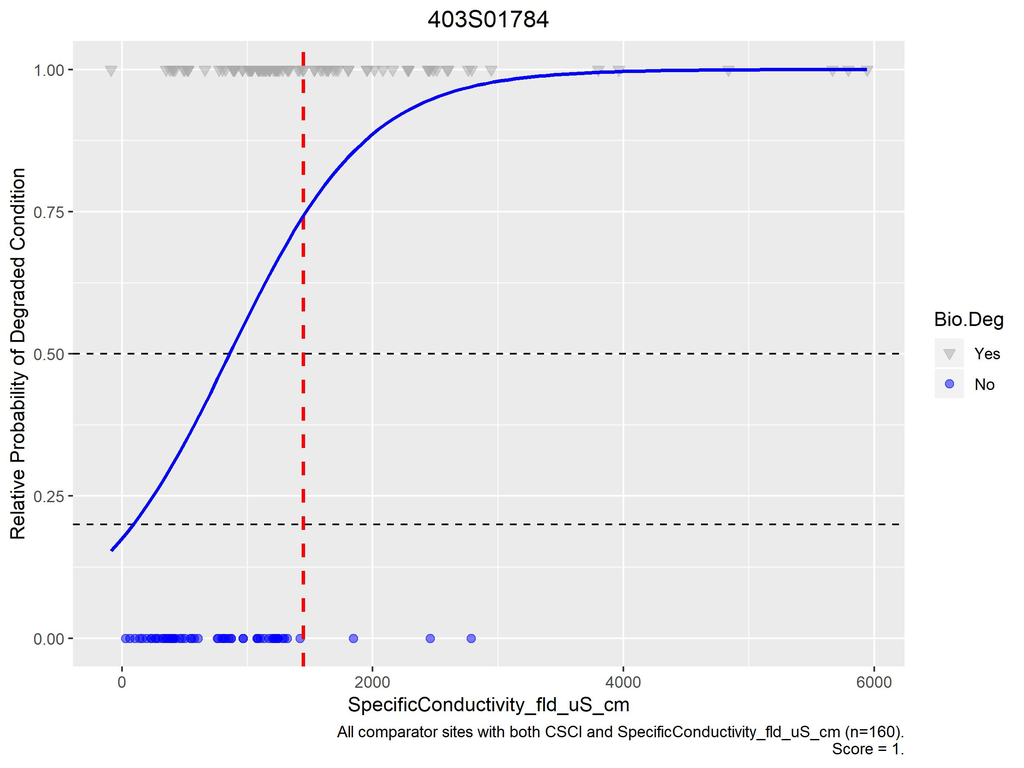